# Clustering Web Readers With Kmeans

### Put it together into a data frame

This step glues the vectors we’ve been building into a data frame where each observation is a website visit. Each row has a subscriber code, a date, and a channel showing the kind of recipe the subscriber was reading.

```r
group_1 <- tibble(sub_code = sample(subscriber_codes[group_1_cutoff], size=group_1_logs, replace = TRUE),
               sys_time = rand.date("2014-01-01","2018-12-31",group_1_logs),
               channel = sample(channels, size=group_1_logs, prob = pr_group_1, replace = TRUE))

group_2 <- tibble(sub_code = sample(subscriber_codes[group_2_cutoff], size=group_2_logs, replace = TRUE),
               sys_time = rand.date("2014-01-01","2018-12-31",group_2_logs),
               channel = sample(channels, size=group_2_logs, prob = pr_group_2, replace = TRUE))

group_3 <- tibble(sub_code = sample(subscriber_codes[group_3_cutoff], size=group_3_logs, replace = TRUE),
               sys_time = rand.date("2014-01-01","2018-12-31",group_3_logs),
               channel = sample(channels, size=group_3_logs, prob = pr_group_3, replace = TRUE))

group_4 <- tibble(sub_code = sample(subscriber_codes[group_4_cutoff], size=group_4_logs, replace = TRUE),
               sys_time = rand.date("2014-01-01","2018-12-31",group_4_logs),
               channel = sample(channels, size=group_4_logs, replace = TRUE))

subs <- bind_rows(group_1, group_2, group_3, group_4)
head(subs)
```

```
## # A tibble: 6 x 3
##   sub_code sys_time   channel
##   <chr>    <date>     <chr>
## 1 EKB445   2014-02-10 soups
## 2 KNN279   2016-10-08 seafood
## 3 RIB118   2018-01-11 sandwiches
## 4 SVL263   2015-07-12 stir_fry
## 5 HLV769   2014-12-16 seafood
## 6 KNN279   2015-04-15 <NA>
```

## Part III: K-means

Now we get to the good part. We’ve just created a weblog with 50,000 records. We can do the clustering process on this data, but we’ll have to start by tranforming it into the right format.

In particular, kmeans requires that the data be uniformly scaled. So if some subscribers are reading hundreds of articles and others are reading just a few, that’s going to distort our results. To weight each subscriber equally, we’ll want to render the data as *proportions* instead of raw weblogs.

In other words, we’re going to look at the percentage of each reader’s total reads that fell into each channel, and then compare that.

### Transform data to show proportion of reading in each channel.

This part is a little tricky. Essentially we’re first counting the views by subscriber, then counting the percentage of those views that took place in each channel.

```r
sub_prop <- subs %>%
    select(-sys_time) %>% # we don't need dates for this part
    filter(!is.na(channel)) %>% # toss records where the channel is NA
    group_by(sub_code) %>%
    mutate(sub_views = sum(n())) %>% # get the total reads per subscriber
    group_by(sub_code, channel, sub_views) %>%
    summarise(sub_channel_views = n()) %>% # get each subscriber's reads in each channel
    mutate(freq = sub_channel_views/sub_views) %>% # render these numbers as a percentage
    arrange(sub_code, desc(freq))

head(sub_prop)
```

```
## # A tibble: 6 x 5
## # Groups:   sub_code, channel [6]
##   sub_code channel    sub_views sub_channel_views   freq
##   <chr>    <chr>          <int>             <int>  <dbl>
## 1 AAH357   seafood           29                20 0.690
## 2 AAH357   soups             29                 6 0.207
## 3 AAH357   salads            29                 2 0.0690
## 4 AAH357   stir_fry          29                 1 0.0345
## 5 AAN399   sandwiches        70                30 0.429
## 6 AAN399   soups             70                30 0.429
```

Now we take each channel’s proportions and put that in its own column. We can use `tidyr::spread()` to get the data into this so-called wide format.

```r
# prep data for k-means
subs_wide <- sub_prop %>%
    select(-sub_views, -sub_channel_views) %>%
    spread(channel, freq)

# Replace NAs with 0
subs_wide[is.na(subs_wide)] <- 0.0

head(subs_wide)
```

```
## # A tibble: 6 x 7
## # Groups:   sub_code [6]
##   sub_code barbecue salads sandwiches seafood soups stir_fry
##   <chr>       <dbl>  <dbl>      <dbl>   <dbl> <dbl>    <dbl>
## 1 AAH357     0      0.0690      0      0.690  0.207   0.0345
## 2 AAN399     0.0429 0.0714      0.429  0.0286 0.429   0
## 3 ABU359     0.0580 0.116       0.246  0.0580 0.507   0.0145
## 4 ACQ152     0.154  0.231       0.154  0.0769 0.231   0.154
## 5 ACU966     0.0506 0.114       0.342  0.0633 0.392   0.0380
## 6 ADW158     0      0.962       0      0.0385 0       0
```

### Execute kmeans algorithm

After all that munging, the actual algorithm takes just one line of code to apply.

Note that we run the algorithm on columns 2 to 7. We’re excluding column 1 because kmeans can only accept numeric data types. Including the subscriber codes in the input will cause R to throw an error.

The plot shows how well our data falls into $k$ clusters. In our case, the data cluster fairly well but notice that there are some ambiguous points. Many of these are the readers in group 4, which read equally in all channels and add a bit of noise to the signal here.

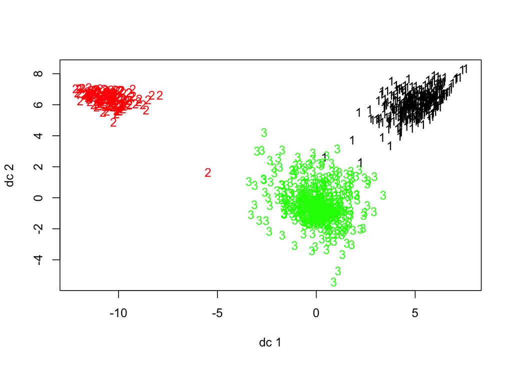

```r
# do kmeans
k_means <- kmeans(subs_wide[2:7], centers = k, nstart = 10, algorithm = "Hartigan-Wong")

# plot kmeans
plotcluster(subs_wide[2:7], k_means$cluster)
```

### Line plot for centers of clusters

Now we are ready to plot the “centroids” returned by kmeans. For each cluster, the kmeans algorithm will return a mean. In our case, this is a mean in n-dimensional space, where $n$ is equal to our number of channels.

```r
# Prepare data for plotting
cent <- k_means$centers %>%
    data.frame() %>%
    rownames_to_column(var = "cluster") %>%
    gather(service, freq, -cluster)

(cluster_count <- length(unique(cent$cluster)))
```

```
## [1] 3
```

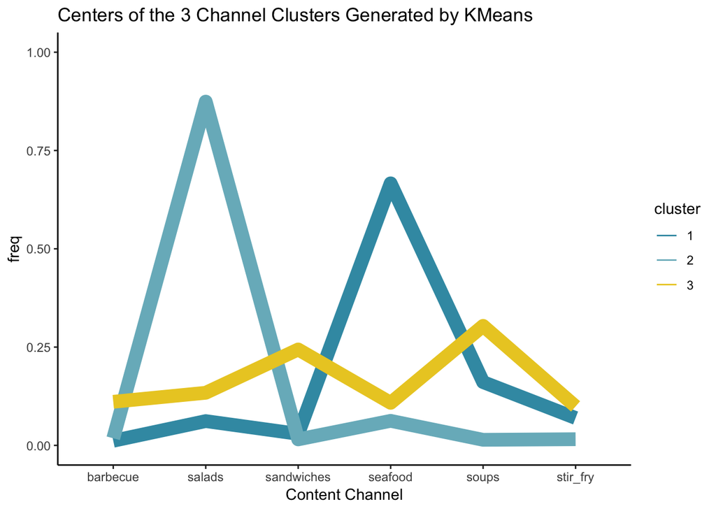

```r
ggplot(cent, aes(x = service, y = freq, group = cluster)) +
    theme_classic() +
    scale_y_continuous(limits = c(0, 1)) +
    geom_line(aes(color = cluster, size = 1)) +
    guides(size = FALSE) +
    labs(x = "Content Channel") +
    ggtitle(paste0("Centers of the ", cluster_count, " Channel Clusters Generated by KMeans")) +
    scale_color_manual(values = wes_palette("Zissou1"))
```